# Data Science mit Python: Abschlussprojekt

## 1. Data scraping / Web scraping

Der Code zum Scrapen ist auskommentiert, damit nicht jedes mal beim ausführen des Notebooks der Datensatz neu erstellt wird. Der Code selbst wurde ursprünglich in VS-Code ausgeführt

```python
# import praw
# import pandas as pd
# from datetime import datetime, timedelta
# import reddit_keys as rk

# # API-Schlüssel und Token
# client_id = rk.CLIENT_ID
# client_secret = rk.CLIENT_SECRET
# user_agent = 'dataScience/0.1 by sombreroKaktus'

# # Authentifizierung
# reddit = praw.Reddit(client_id=client_id,
#                      client_secret=client_secret,
#                      user_agent=user_agent)

# # Funktion zum Scrapen von Reddit-Posts mit Zeitfilter
# def scrape_reddit(subreddit_name, query, max_results, start_date, end_date):
#     subreddit = reddit.subreddit(subreddit_name)
#     posts = []
#     for submission in subreddit.search(query, limit=max_results):
#         submission_date = datetime.fromtimestamp(submission.created)
#         if start_date <= submission_date <= end_date:
#             posts.append({
#                 'subreddit': subreddit_name,
#                 'hashtag': query,
#                 'title': submission.title,
#                 'score': submission.score,
#                 'id': submission.id,
#                 'url': submission.url,
#                 'num_comments': submission.num_comments,
#                 'created': submission_date,
#                 'body': submission.selftext,
#                 'author': submission.author.name if submission.author else 'N/A'
#             })
#     return posts

# # Liste von Subreddits
# subreddits = ['europe', 'eu', 'EuropeanFederalists', 'EuropeanPolitics', 'de', 'deutschland', 'germany', 'politik', 'PolitikBRD', 'AskAGerman', 'Austria', 'europeanunion']

# # Liste von Parteien mit Kurzbezeichnungen und vollständigen Namen
# parties = [
#     {"short": "CDU", "name": "Christlich Demokratische Union Deutschlands"},
#     {"short": "GRÜNE", "name": "BÜNDNIS 90/DIE GRÜNEN"},
#     {"short": "SPD", "name": "Sozialdemokratische Partei Deutschlands"},
#     {"short": "AfD", "name": "Alternative für Deutschland"},
#     {"short": "CSU", "name": "Christlich-Soziale Union in Bayern e.V."},
#     {"short": "DIE LINKE", "name": "DIE LINKE"},
#     {"short": "FDP", "name": "Freie Demokratische Partei"},
#     {"short": "Die PARTEI", "name": "Partei für Arbeit, Rechtsstaat, Tierschutz, Elitenförderung und basisdemokratische Initiative"},
#     {"short": "FREIE WÄHLER", "name": "FREIE WÄHLER"},
#     {"short": "Tierschutzpartei", "name": "PARTEI MENSCH UMWELT TIERSCHUTZ"},
#     {"short": "ÖDP", "name": "Ökologisch-Demokratische Partei, Die Naturschutzpartei"},
#     {"short": "FAMILIE", "name": "Familien-Partei Deutschlands"},
#     {"short": "Volt", "name": "Volt Deutschland"},
#     {"short": "PIRATEN", "name": "Piratenpartei Deutschland"},
#     {"short": "MERA25", "name": "MERA25 - Gemeinsam für Europäische Unabhängigkeit"},
#     {"short": "HEIMAT", "name": "Die Heimat"},
#     {"short": "TIERSCHUTZ hier!", "name": "Aktion Partei für Tierschutz"},
#     {"short": "-", "name": "Partei für schulmedizinische Verjüngungsforschung"},
#     {"short": "BIG", "name": "Bündnis für Innovation & Gerechtigkeit"},
#     {"short": "Bündnis C", "name": "Bündnis C - Christen für Deutschland"},
#     {"short": "PdH", "name": "Partei der Humanisten"},
#     {"short": "MENSCHLICHE WELT", "name": "Menschliche Welt, für das Wohl und Glücklichsein aller"},
#     {"short": "DKP", "name": "Deutsche Kommunistische Partei"},
#     {"short": "MLPD", "name": "Marxistisch-Leninistische Partei Deutschlands"},
#     {"short": "SGP", "name": "Sozialistische Gleichheitspartei, Vierte Internationale"},
#     {"short": "ABG", "name": "Aktion Bürger für Gerechtigkeit"},
#     {"short": "dieBasis", "name": "Basisdemokratische Partei Deutschland"},
#     {"short": "BÜNDNIS DEUTSCHLAND", "name": "BÜNDNIS DEUTSCHLAND"},
#     {"short": "BSW", "name": "Bündnis Sahra Wagenknecht - Vernunft und Gerechtigkeit"},
#     {"short": "DAVA", "name": "Demokratische Allianz für Vielfalt und Aufbruch"},
#     {"short": "KLIMALISTE", "name": "Klimaliste Deutschland"},
#     {"short": "LETZTE GENERATION", "name": "Parlament aufmischen – Stimme der Letzten Generation"},
#     {"short": "PDV", "name": "Partei der Vernunft"},
#     {"short": "PdF", "name": "Partei des Fortschritts"},
#     {"short": "V-Partei³", "name": "V-Partei³ - Partei für Veränderung, Vegetarier und Veganer"}
# ]

# # Zeitraum (letzte 6 Monate)
# end_date = datetime.now()
# start_date = end_date - timedelta(days=180)

# posts_total = 0
# # Scrapen und Speichern der Daten
# for subreddit in subreddits:
#     all_posts = []
#     max_results = 125
#     for party in parties:
#         # Scrape sowohl nach Kurzbezeichnung als auch nach vollständigem Namen
#         posts_data_short = scrape_reddit(subreddit, party["short"], max_results, start_date, end_date)
#         posts_data_name = scrape_reddit(subreddit, party["name"], max_results, start_date, end_date)

#         # Daten zusammenenführen
#         all_posts.extend(posts_data_short)
#         all_posts.extend(posts_data_name)

#     # Daten in DataFrame speichern
#     df = pd.DataFrame(all_posts)

#     # Speicherpfad für die CSV-Dateien
#     csv_filename = f'C:\\Users\\Diego\\Desktop\\Medieninformatik\\4 Semester\\Data Science\\Projekt\\Data\\reddit_posts_{subreddit}.csv'
#     #Simikolon als Trennzeichen für Exel
#     df.to_csv(csv_filename, index=False, sep=';', encoding='utf-8-sig')

#     print(f'{len(all_posts)} Posts wurden erfolgreich gescrapt und in {csv_filename} gespeichert.')
#     posts_total = posts_total + len(all_posts)

# print(f'Insgesamt wurden {posts_total} Posts gescrapt und gespeichert')
```

## 2. Datenbereinigung

```python
import pandas as pd
import matplotlib.pyplot as plt
from collections import Counter
from datetime import datetime
import seaborn as sns
```

#### Definition der Partein:

```python
parties = [
    {"short": "CDU", "name": "Christlich Demokratische Union Deutschlands"},
    {"short": "GRÜNE", "name": "BÜNDNIS 90/DIE GRÜNEN"},
    {"short": "SPD", "name": "Sozialdemokratische Partei Deutschlands"},
    {"short": "AfD", "name": "Alternative für Deutschland"},
    {"short": "CSU", "name": "Christlich-Soziale Union in Bayern e.V."},
    {"short": "DIE LINKE", "name": "DIE LINKE"},
    {"short": "FDP", "name": "Freie Demokratische Partei"},
    {"short": "Die PARTEI", "name": "Partei für Arbeit, Rechtsstaat, Tierschutz, Elitenförderung und basisdemokratische Initiative"},
    {"short": "FREIE WÄHLER", "name": "FREIE WÄHLER"},
    {"short": "Tierschutzpartei", "name": "PARTEI MENSCH UMWELT TIERSCHUTZ"},
    {"short": "ÖDP", "name": "Ökologisch-Demokratische Partei, Die Naturschutzpartei"},
    {"short": "FAMILIE", "name": "Familien-Partei Deutschlands"},
    {"short": "Volt", "name": "Volt Deutschland"},
    {"short": "PIRATEN", "name": "Piratenpartei Deutschland"},
    {"short": "MERA25", "name": "MERA25 - Gemeinsam für Europäische Unabhängigkeit"},
    {"short": "HEIMAT", "name": "Die Heimat"},
    {"short": "TIERSCHUTZ hier!", "name": "Aktion Partei für Tierschutz"},
    {"short": "Partei für schulmedizinische Verjüngungsforschung", "name": "Partei für schulmedizinische Verjüngungsforschung"},
    {"short": "BIG", "name": "Bündnis für Innovation & Gerechtigkeit"},
    {"short": "Bündnis C", "name": "Bündnis C - Christen für Deutschland"},
    {"short": "PdH", "name": "Partei der Humanisten"},
    {"short": "MENSCHLICHE WELT", "name": "Menschliche Welt, für das Wohl und Glücklichsein aller"},
    {"short": "DKP", "name": "Deutsche Kommunistische Partei"},
    {"short": "MLPD", "name": "Marxistisch-Leninistische Partei Deutschlands"},
    {"short": "SGP", "name": "Sozialistische Gleichheitspartei, Vierte Internationale"},
    {"short": "ABG", "name": "Aktion Bürger für Gerechtigkeit"},
    {"short": "dieBasis", "name": "Basisdemokratische Partei Deutschland"},
    {"short": "BÜNDNIS DEUTSCHLAND", "name": "BÜNDNIS DEUTSCHLAND"},
    {"short": "BSW", "name": "Bündnis Sahra Wagenknecht - Vernunft und Gerechtigkeit"},
    {"short": "DAVA", "name": "Demokratische Allianz für Vielfalt und Aufbruch"},
    {"short": "KLIMALISTE", "name": "Klimaliste Deutschland"},
    {"short": "LETZTE GENERATION", "name": "Parlament aufmischen – Stimme der Letzten Generation"},
    {"short": "PDV", "name": "Partei der Vernunft"},
    {"short": "PdF", "name": "Partei des Fortschritts"},
    {"short": "V-Partei³", "name": "V-Partei³ - Partei für Veränderung, Vegetarier und Veganer"}
]
```

#### Funktion zum Bereinigen der Daten:

```python
def clean_data(df):
    initial_count = len(df)

    # Überprüfen auf fehlende Werte
    missing_values = df.isnull().sum()
    print("Fehlende Werte pro Spalte:")
    print(missing_values)

    # Entfernen von Zeilen mit fehlenden wichtigen Informationen
    df_cleaned = df.dropna(subset=['title', 'body', 'created'])

    # Entfernen von Duplikaten
    df_cleaned = df_cleaned.drop_duplicates(subset=['title', 'body', 'hashtag'])

    # Anzahl der entfernten Beiträge berechnen
    final_count = len(df_cleaned)
    removed_count = initial_count - final_count
    print(f"Anzahl der entfernten Beiträge: {removed_count}")
    print()

    return df_cleaned
```

#### Skript zum bereinigen der Daten:

```python
# Laden der gescrapten Daten
subreddits = ['europe', 'eu', 'EuropeanFederalists', 'EuropeanPolitics', 'de', 'deutschland', 'germany', 'politik', 'PolitikBRD', 'AskAGerman', 'Austria', 'europeanunion']
data_path = 'C:\\Users\\Diego\\Desktop\\Medieninformatik\\4 Semester\\Data Science\\Projekt\\Data\\'

all_dataframes = []
for subreddit in subreddits:
    csv_filename = f'{data_path}reddit_posts_{subreddit}.csv'
    df = pd.read_csv(csv_filename, sep=';', encoding='utf-8-sig')
    df_cleaned = clean_data(df)
    all_dataframes.append(df_cleaned)

# Zusammenführen aller bereinigten Daten
df_all = pd.concat(all_dataframes, ignore_index=True)

# Überprüfen, welche Parteien keine Einträge haben und entfernen
removed_parties = []
parties_with_data = []
for party in parties:
    if not df_all['body'].str.contains(party['short'], case=False, na=False).any() and not df_all['body'].str.contains(party['name'], case=False, na=False).any() and \
       not df_all['title'].str.contains(party['short'], case=False, na=False).any() and not df_all['title'].str.contains(party['name'], case=False, na=False).any():
        removed_parties.append(party['name'])
    else:
        parties_with_data.append(party)

# Textausgabe der entfernten Parteien
print("Folgende Parteien wurden entfernt, da keine Einträge gespeichert wurden:")
counter = 0
for party in removed_parties:
    print(f"{counter}. {party}")
    counter += 1


# Erstellt ein mapping dictionary zum Zuordnen von name zu short
mapping = {party['name']: party['short'] for party in parties}
mapping.update({party['short']: party['short'] for party in parties})

# Funktion zur Zuordnung von Hashtags zu Kurzformen
def map_to_short(hashtag):
    return mapping.get(hashtag, hashtag)

# Erzeugt neue Spalte die die Kurzform der hashtags enthält
df_all['main_hashtag'] = df_all['hashtag'].apply(map_to_short)

df_all = df_all[df_all.hashtag!='-']

#Speichern der bereinigten Daten in einer neuen CSV-Datei
df_all.to_csv(f'{data_path}cleaned_reddit_korpus.csv', index=False, sep=';', encoding='utf-8-sig')

print(f"Daten wurden bereinigt und in 'cleaned_reddit_korpus.csv' gespeichert.")
print(f"Gesamtanzahl der Beiträge nach Bereinigung: {len(df_all)}")

# Aktualisieren der Liste parties
parties = parties_with_data
```

```
Fehlende Werte pro Spalte:
subreddit         0
hashtag           0
title             0
score             0
id                0
url               0
num_comments      0
created           0
body            287
author            0
dtype: int64
Anzahl der entfernten Beiträge: 288

Fehlende Werte pro Spalte:
subreddit       0
hashtag         0
title           0
score           0
id              0
url             0
num_comments    0
created         0
body            8
author          0
dtype: int64
Anzahl der entfernten Beiträge: 9

Fehlende Werte pro Spalte:
subreddit        0
hashtag          0
title            0
score            0
id               0
url              0
num_comments     0
created          0
body            38
author           0
dtype: int64
```

[output cut: 128 more lines]

```
Folgende Parteien wurden entfernt, da keine Einträge gespeichert wurden:
0. Aktion Partei für Tierschutz
1. Partei für schulmedizinische Verjüngungsforschung
2. Bündnis C - Christen für Deutschland
3. Partei der Humanisten
4. Menschliche Welt, für das Wohl und Glücklichsein aller
5. Deutsche Kommunistische Partei
6. Marxistisch-Leninistische Partei Deutschlands
7. Sozialistische Gleichheitspartei, Vierte Internationale
8. Basisdemokratische Partei Deutschland
9. Klimaliste Deutschland
10. Partei der Vernunft
11. V-Partei³ - Partei für Veränderung, Vegetarier und Veganer
Daten wurden bereinigt und in 'cleaned_reddit_korpus.csv' gespeichert.
Gesamtanzahl der Beiträge nach Bereinigung: 2175
```

```python
#mapping
```

```python
#df_all.shape
```

```python
#df_all['main_hashtag'].value_counts()
```

```python
df_all.groupby('main_hashtag').agg(
    count=('id', 'size'),
    unique_count=('id', 'nunique')
).reset_index().sort_values(by='count',ascending=False).sum()
```

```
main_hashtag    AfDMENSCHLICHE WELTDie PARTEIFAMILIEPdFBIGDIE ...
count                                                        2175
unique_count                                                 2071
dtype: object
```

#### Manche Posts wurden für die selbe Partei mit verschiedenen Queries mehrmals gescraped (z.B. jeweils für AfD & Alternative für Deutschland)

Duplikate werden entfernt

```python
df_all = df_all.drop_duplicates(subset=['main_hashtag', 'id'])
```

```python
df_all.shape
```

```
(2071, 11)
```

## 3. Datenanalyse, Datenvisualisierung

```python
from textblob import TextBlob
```

### 3.1. Häufigkeit der Erwähnung pro Partei

- Frage: Wie oft werden die verschiedenen Parteien auf Reddit erwähnt?
- Vorgehen: Die Anzahl der Erwähnungen jeder Partei im Korpus zählen
- Visualisierung: Balkendiagramm

#### Analyse:

```python
# Erstellen eines Dataframes für Erwähnungen nach Partei
mentions_df = df_all.groupby('main_hashtag').id.nunique().reset_index()

mentions_df.columns = ['Partei', 'Erwähnungen']
mentions_df.sort_values(by='Erwähnungen',ascending=False)
```

|  | Partei | Erwähnungen |
| --- | --- | --- |
| 1 | AfD | 303 |
| 18 | MENSCHLICHE WELT | 280 |
| 11 | Die PARTEI | 196 |
| 12 | FAMILIE | 163 |
| 23 | PdF | 135 |
| 2 | BIG | 126 |
| 9 | DIE LINKE | 95 |
| 21 | PDV | 91 |
| 24 | PdH | 91 |
| 6 | CDU | 85 |
| 25 | SPD | 59 |
| 5 | Bündnis C | 52 |
| 13 | FDP | 52 |
| 30 | dieBasis | 48 |
| 15 | GRÜNE | 31 |
| 19 | MERA25 | 29 |
| 8 | DAVA | 28 |
| 3 | BSW | 28 |
| 17 | LETZTE GENERATION | 28 |
| 29 | Volt | 26 |
| 28 | V-Partei³ | 24 |
| 16 | HEIMAT | 24 |
| 20 | MLPD | 19 |
| 7 | CSU | 18 |
| 0 | ABG | 10 |
| 10 | DKP | 10 |
| 27 | Tierschutzpartei | 5 |
| 14 | FREIE WÄHLER | 5 |
| 4 | BÜNDNIS DEUTSCHLAND | 3 |
| 31 | ÖDP | 3 |
| 22 | PIRATEN | 2 |
| 26 | TIERSCHUTZ hier! | 2 |

#### Visualisierung:

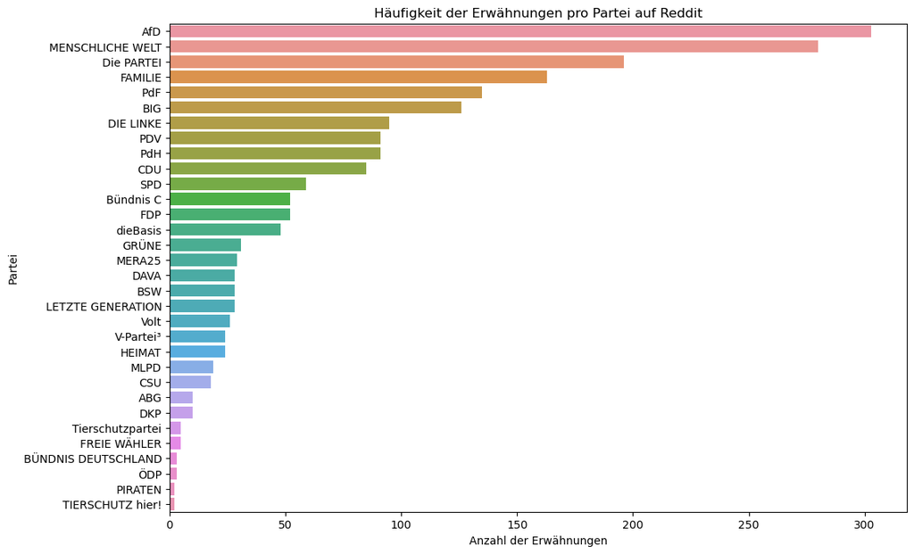

```python
# Visualisierung der Erwähnungen pro Partei
plt.figure(figsize=(12, 8))
sns.barplot(x='Erwähnungen', y='Partei', data=mentions_df.sort_values('Erwähnungen', ascending=False))
plt.xlabel('Anzahl der Erwähnungen')
plt.ylabel('Partei')
plt.title('Häufigkeit der Erwähnungen pro Partei auf Reddit')
plt.show()
```

#### Interpretation:

Der erste Abschnitt der Datenanalyse untersucht die Häufigkeit der Erwähnungen verschiedener politischer Parteien auf Reddit. Dabei wurden sowohl die Kurz- als auch die Langbezeichnungen der Parteien in den Beiträgen und Titeln auf Reddit gezählt.

Das Balkendiagramm zeigt die Anzahl der Erwähnungen für jede Partei. Die Daten wurden so aufbereitet, dass die Parteien mit den meisten Erwähnungen oben und die mit den wenigsten Erwähnungen unten gelistet sind.

1. AfD (Alternative für Deutschland):

Mit 303 Erwähnungen steht die AfD an der Spitze der Liste. Dies deutet darauf hin, dass die AfD häufig im Mittelpunkt der Diskussionen auf Reddit steht. Dies könnte auf ihre kontroversen politischen Positionen und die starke Polarisierung in der Öffentlichkeit zurückzuführen sein.

2. MENSCHLICHE WELT:

Diese Partei belegt mit 280 Erwähnungen den zweiten Platz. Die hohe Anzahl an Erwähnungen könnte durch spezifische Kampagnen oder aktuelle Themen verursacht worden sein, die von dieser Partei aufgegriffen wurden.

3. Die PARTEI:

Mit 196 Erwähnungen ist Die PARTEI ebenfalls prominent vertreten. Die PARTEI ist bekannt für ihre satirische Herangehensweise an Politik, was zu erhöhter Aufmerksamkeit und Diskussionen auf Plattformen wie Reddit führen kann.

4. FAMILIE und PdF:

Diese Parteien sind mit 163 bzw. 135 Erwähnungen ebenfalls häufig genannt. Dies könnte auf spezifische politische Initiativen oder aktuelle Diskussionen zurückzuführen sein, die diese Parteien betreffen.

5. Größere etablierte Parteien:

Parteien wie die CDU (85 Erwähnungen), SPD (59 Erwähnungen), GRÜNE (31 Erwähnungen) und FDP (52 Erwähnungen) haben relativ weniger Erwähnungen. Dies könnte darauf hindeuten, dass die Diskussionen über etablierte Parteien weniger intensiv oder weniger kontrovers sind als die über kleinere oder neue Parteien.

6. Kleinere Parteien:

Parteien wie die Piratenpartei (2 Erwähnungen) und die ÖDP (3 Erwähnungen) haben sehr wenige Erwähnungen. Dies könnte auf eine geringere öffentliche Präsenz oder weniger relevante aktuelle Themen zurückzuführen sein.

7. Auffällige Ausreißer:

Parteien wie FREIE WÄHLER und TIERSCHUTZ hier! mit nur 5 bzw. 2 Erwähnungen fallen durch besonders wenige Erwähnungen auf. Dies deutet darauf hin, dass diese Parteien derzeit wenig im Fokus der öffentlichen Diskussionen stehen.

Fazit: Die Analyse der Häufigkeit der Erwähnungen zeigt ein differenziertes Bild der politischen Diskussionen auf Reddit. Parteien wie die AfD und MENSCHLICHE WELT dominieren die Diskussionen, während etablierte Parteien wie die CDU, SPD und GRÜNE weniger häufig erwähnt werden. Kleinere Parteien haben tendenziell weniger Erwähnungen, was auf eine geringere öffentliche Präsenz hinweisen könnte.

### 3.2. Allgemeine Popularität der Parteien:

- Frage: Wie viele Interaktionen hat eine Partei im Schnitt (Votes, Kommentare)?
- Vorgehen: Filtern der Beiträge, die eine Partei im Titel oder im Text erwähnen Berechnen der durchschnittlichen Anzahl der Kommentare und Upvotes pro Beitrag für jede Partei
- Visualisierung: Balkendiagramm

#### Analyse:

```python
average_interactions_df = df_all.groupby('main_hashtag').agg(
    count=('id','nunique'),
    avg_score=('score', 'mean'),
    median_score=('score', 'median'),
    avg_comments=('num_comments', 'mean'),
    median_comments=('num_comments', 'median'),
).reset_index()

average_interactions_df.columns = ['Partei', 'Anzahl Beiträge','Durchschnittliche Upvotes', 'Median Upvotes','Durchschnittliche Kommentare', 'Median Kommentare' ]
average_interactions_df
```

|  | Partei | Anzahl Beiträge | Durchschnittliche Upvotes | Median Upvotes | Durchschnittliche Kommentare | Median Kommentare |
| --- | --- | --- | --- | --- | --- | --- |
| 0 | ABG | 10 | 11.600000 | 0.0 | 28.900000 | 11.0 |
| 1 | AfD | 303 | 62.815182 | 5.0 | 64.052805 | 18.0 |
| 2 | BIG | 126 | 65.055556 | 5.0 | 80.880952 | 34.0 |
| 3 | BSW | 28 | 56.785714 | 4.5 | 118.928571 | 13.0 |
| 4 | BÜNDNIS DEUTSCHLAND | 3 | 8.000000 | 5.0 | 1.000000 | 1.0 |
| 5 | Bündnis C | 52 | 66.846154 | 10.0 | 58.500000 | 17.0 |
| 6 | CDU | 85 | 55.058824 | 5.0 | 43.247059 | 12.0 |
| 7 | CSU | 18 | 71.666667 | 3.0 | 109.222222 | 25.0 |
| 8 | DAVA | 28 | 19.357143 | 3.0 | 34.857143 | 8.5 |
| 9 | DIE LINKE | 95 | 53.747368 | 5.0 | 71.347368 | 12.0 |
| 10 | DKP | 10 | 40.900000 | 0.5 | 20.900000 | 18.5 |
| 11 | Die PARTEI | 196 | 74.535714 | 6.5 | 72.948980 | 24.0 |
| 12 | FAMILIE | 163 | 41.650307 | 1.0 | 51.251534 | 12.0 |
| 13 | FDP | 52 | 62.826923 | 5.5 | 73.519231 | 8.5 |
| 14 | FREIE WÄHLER | 5 | 95.000000 | 6.0 | 482.200000 | 9.0 |
| 15 | GRÜNE | 31 | 108.935484 | 15.0 | 109.193548 | 24.0 |
| 16 | HEIMAT | 24 | 44.458333 | 4.0 | 62.833333 | 22.5 |
| 17 | LETZTE GENERATION | 28 | 127.178571 | 19.5 | 75.500000 | 46.0 |
| 18 | MENSCHLICHE WELT | 280 | 92.953571 | 6.0 | 61.671429 | 15.0 |
| 19 | MERA25 | 29 | 84.103448 | 18.0 | 54.620690 | 14.0 |
| 20 | MLPD | 19 | 28.052632 | 4.0 | 141.315789 | 14.0 |
| 21 | PDV | 91 | 36.428571 | 5.0 | 50.230769 | 22.0 |
| 22 | PIRATEN | 2 | 3.500000 | 3.5 | 11.500000 | 11.5 |
| 23 | PdF | 135 | 29.518519 | 1.0 | 45.651852 | 8.0 |
| 24 | PdH | 91 | 36.098901 | 5.0 | 50.582418 | 24.0 |
| 25 | SPD | 59 | 20.864407 | 3.0 | 58.203390 | 13.0 |
| 26 | TIERSCHUTZ hier! | 2 | 146.000000 | 146.0 | 41.000000 | 41.0 |
| 27 | Tierschutzpartei | 5 | 99.600000 | 18.0 | 474.600000 | 24.0 |
| 28 | V-Partei³ | 24 | 63.166667 | 6.0 | 27.125000 | 23.0 |
| 29 | Volt | 26 | 40.038462 | 14.0 | 148.576923 | 17.0 |
| 30 | dieBasis | 48 | 46.854167 | 4.5 | 80.625000 | 21.5 |
| 31 | ÖDP | 3 | 147.666667 | 4.0 | 766.333333 | 26.0 |

#### Visualisierung:

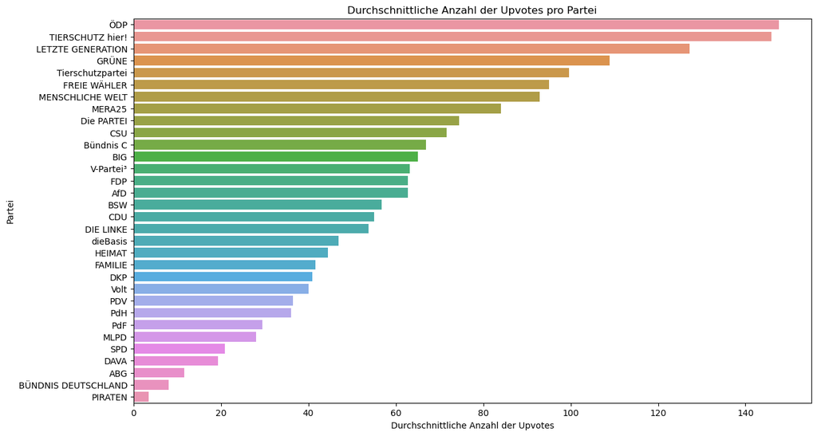

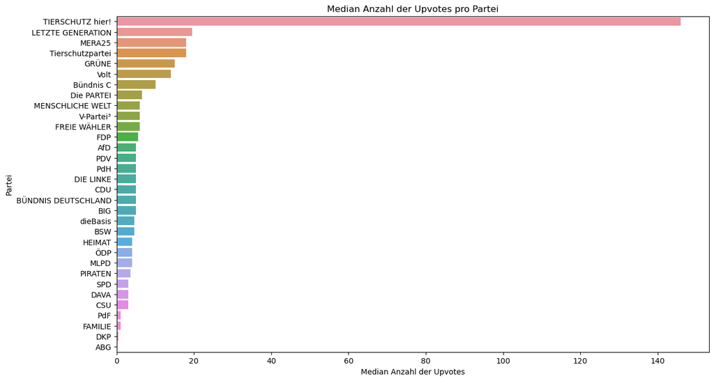

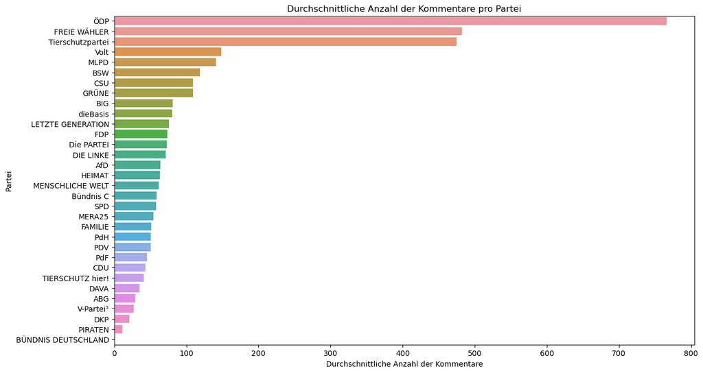

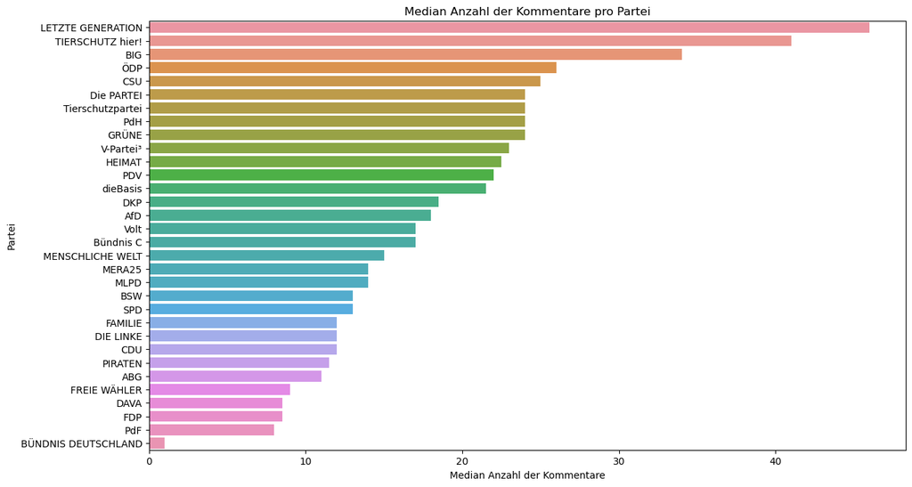

```python
# Visualisierung der durchschnittlichen Upvotes pro Partei
plt.figure(figsize=(14, 8))
sns.barplot(x='Durchschnittliche Upvotes', y='Partei', data=average_interactions_df.sort_values('Durchschnittliche Upvotes', ascending=False))
plt.xlabel('Durchschnittliche Anzahl der Upvotes')
plt.ylabel('Partei')
plt.title('Durchschnittliche Anzahl der Upvotes pro Partei')
plt.show()

# Visualisierung der durchschnittlichen Upvotes pro Partei
plt.figure(figsize=(14, 8))
sns.barplot(x='Median Upvotes', y='Partei', data=average_interactions_df.sort_values('Median Upvotes', ascending=False))
plt.xlabel('Median Anzahl der Upvotes')
plt.ylabel('Partei')
plt.title('Median Anzahl der Upvotes pro Partei')
plt.show()


# Visualisierung der durchschnittlichen Kommentare pro Partei
plt.figure(figsize=(14, 8))
sns.barplot(x='Durchschnittliche Kommentare', y='Partei', data=average_interactions_df.sort_values('Durchschnittliche Kommentare', ascending=False))
plt.xlabel('Durchschnittliche Anzahl der Kommentare')
plt.ylabel('Partei')
plt.title('Durchschnittliche Anzahl der Kommentare pro Partei')
plt.show()

# Visualisierung der durchschnittlichen Kommentare pro Partei
plt.figure(figsize=(14, 8))
sns.barplot(x='Median Kommentare', y='Partei', data=average_interactions_df.sort_values('Median Kommentare', ascending=False))
plt.xlabel('Median Anzahl der Kommentare')
plt.ylabel('Partei')
plt.title('Median Anzahl der Kommentare pro Partei')
plt.show()
```

### Interpretation:

##### Überblick über die Daten:

Die Daten sind in folgenden Aspekten analysiert:

1. Anzahl der Beiträge: Die absolute Anzahl der Beiträge, die jede Partei erwähnt.
2. Durchschnittliche Upvotes: Die durchschnittliche Anzahl der Upvotes, die Beiträge zu jeder Partei erhalten.
3. Median-Upvotes: Der Median der Upvotes, um Extremwerte zu berücksichtigen.
4. Durchschnittliche Kommentare: Die durchschnittliche Anzahl der Kommentare zu Beiträgen über jede Partei.
5. Median-Kommentare: Der Median der Kommentare, um Extremwerte zu berücksichtigen.

##### Visualisierungen:

1. Durchschnittliche Anzahl der Kommentare pro Partei:
- ÖDP: Mit den höchsten durchschnittlichen Kommentaren, möglicherweise aufgrund spezifischer Diskussionen oder Kontroversen.
- Freie Wähler: Ebenfalls sehr hohe durchschnittliche Kommentare, was auf intensive Diskussionen hinweist.
- Tierschutzpartei: Hohe Kommentardurchschnitt, wahrscheinlich aufgrund von emotional geladenen Themen wie Tierschutz.
2. Durchschnittliche Anzahl der Upvotes pro Partei:
- ÖDP: Erhält die höchste durchschnittliche Anzahl an Upvotes, was auf eine starke Zustimmung oder Unterstützung hinweist.
- TIERSCHUTZ hier!: Ebenfalls sehr hohe Upvotes, was auf hohe Zustimmung oder Popularität in den Diskussionen hinweist.
- LETZTE GENERATION: Hohe Upvotes, was auf starke Unterstützung oder Zustimmung hindeutet.
3. Median Anzahl der Kommentare pro Partei:
- LETZTE GENERATION: Hat den höchsten Median an Kommentaren, was auf konsistente Diskussionen hinweist.
- TIERSCHUTZ hier!: Ebenfalls hohe Median-Kommentare, was auf kontinuierliche Diskussionen hinweist.
- BIG: Hohe Median-Kommentare, was auf regelmäßige und intensive Diskussionen hinweist.
4. Median Anzahl der Upvotes pro Partei:
- TIERSCHUTZ hier!: Hat den höchsten Median an Upvotes, was auf konsistente Unterstützung oder Zustimmung hinweist.
- LETZTE GENERATION: Hohe Median-Upvotes, was auf konsistente Unterstützung hinweist.
- MERA25: Hohe Median-Upvotes, was auf regelmäßige Zustimmung hinweist.

### 3.3. Sentiment-Analyse

- Frage: Wie ist die Stimmung der Beiträge, die die verschiedenen Partein erwähnen?
- Vorgehen: Sentiment-Analyse der Beiträge durch kategorisieren in postive, neutrale und negative Stimmung, mittels TextBlob
- Visualisierung: Gestapeltes Balkendiagramm

#### Analyse:

```python
# Sentiment-Analyse durchführen
def get_sentiment(text):
    analysis = TextBlob(text)
    if analysis.sentiment.polarity > 0:
        return 'positive'
    elif analysis.sentiment.polarity < 0:
        return 'negative'
    else:
        return 'neutral'
```

##### Zwischenergebnisse für mich, zum überprüfen der Daten

```python
df_all['sentiment'] = df_all['body'].apply(get_sentiment)
df_all.head(5)
```

|  | subreddit | hashtag | title | score | id | url | num_comments | created | body | author | main_hashtag | sentiment |
| --- | --- | --- | --- | --- | --- | --- | --- | --- | --- | --- | --- | --- |
| 0 | europe | CDU | If next Sunday really were a federal election ... | 843 | 194qwk6 | https://i.redd.it/kj45rngx7zbc1.jpeg | 338 | 2024-01-12 10:16:08 | The drop in polls for BSW is astonishing. In a... | Nohomeoffice | CDU | positive |
| 1 | europe | CDU | After 4 years of investigation, the Munich Pub... | 146 | 1aelom1 | https://www.tagesspiegel.de/politik/axel-fisch... | 6 | 2024-01-30 11:50:29 | Caviar Diplomacy.\n\nAdditionally, two ex-Germ... | Mobile-Ad-5052 | CDU | neutral |
| 2 | europe | GRÜNE | If next Sunday really were a federal election ... | 838 | 194qwk6 | https://i.redd.it/kj45rngx7zbc1.jpeg | 338 | 2024-01-12 10:16:08 | The drop in polls for BSW is astonishing. In a... | Nohomeoffice | GRÜNE | positive |
| 3 | europe | GRÜNE | WWF evaluated all parties in the European Parl... | 0 | 1c5dsqr | https://i.redd.it/s6pqzh1vutuc1.jpeg | 16 | 2024-04-16 13:32:32 | The screenshot only shows members of the EFA/G... | dracona94 | GRÜNE | positive |
| 4 | europe | GRÜNE | 2024 European Parliament elections | 215 | 1db2gua | https://www.reddit.com/r/europe/comments/1db2g... | 969 | 2024-06-08 15:01:25 | The time has come. This week, citizens of Euro... | pothkan | GRÜNE | positive |

```python
sentiment_df = df_all[['main_hashtag','sentiment']]
sentiment_df.columns = ['Partei', 'Sentiment']
sentiment_df
```

|  | Partei | Sentiment |
| --- | --- | --- |
| 0 | CDU | positive |
| 1 | CDU | neutral |
| 2 | GRÜNE | positive |
| 3 | GRÜNE | positive |
| 4 | GRÜNE | positive |
| ... | ... | ... |
| 2414 | Volt | positive |
| 2426 | BIG | positive |
| 2427 | BIG | positive |
| 2428 | MENSCHLICHE WELT | neutral |
| 2429 | DAVA | positive |

2071 rows × 2 columns

```python
sentiment_df.groupby('Partei').value_counts()
```

```
Partei    Sentiment
ABG       positive       5
          neutral        3
          negative       2
AfD       neutral      146
          positive     120
                      ...
dieBasis  neutral       24
          positive      19
          negative       5
ÖDP       neutral        2
          positive       1
Name: count, Length: 88, dtype: int64
```

#### Visualisierung:

- Sentimentverteilung aller Parteien nach Anzahl der Beiträge:

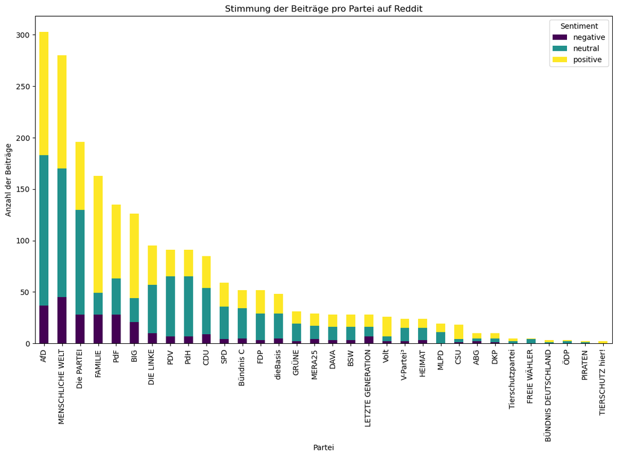

```python
# Visualisierung der Sentiments pro Partei
sentiment_counts = sentiment_df.groupby(['Partei', 'Sentiment']).size().unstack(fill_value=0)
sentiment_counts = sentiment_counts.loc[sentiment_counts.sum(axis=1).sort_values(ascending=False).index]

# Erstellen des gestapelten Balkendiagramms
sentiment_counts.plot(kind='bar', stacked=True, figsize=(14, 8), colormap='viridis')
plt.xlabel('Partei')
plt.ylabel('Anzahl der Beiträge')
plt.title('Stimmung der Beiträge pro Partei auf Reddit')
plt.legend(title='Sentiment')
plt.show()
```

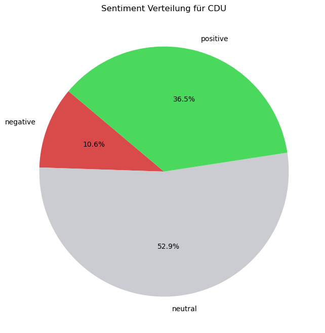

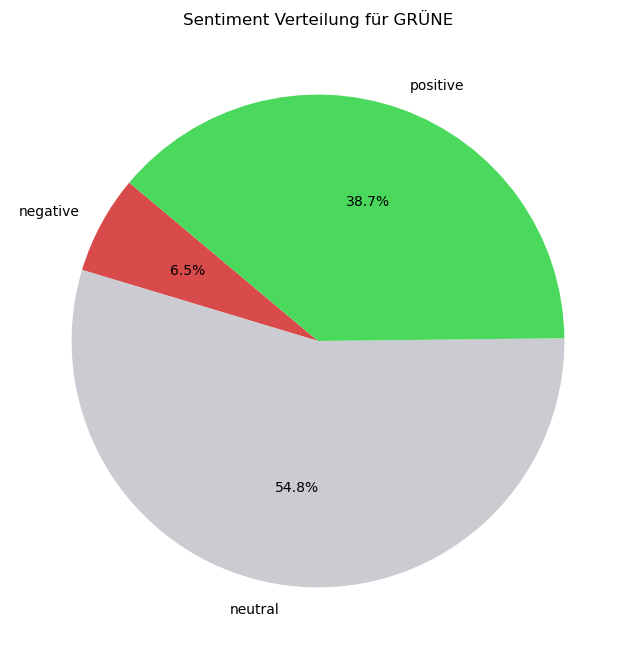

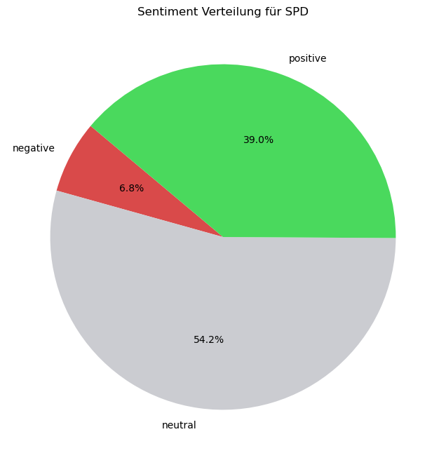

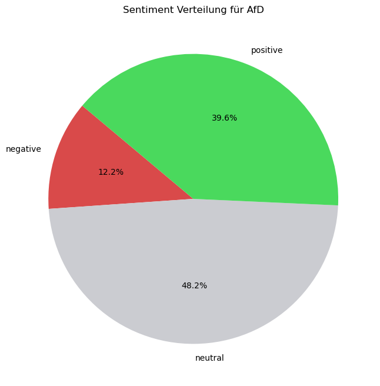

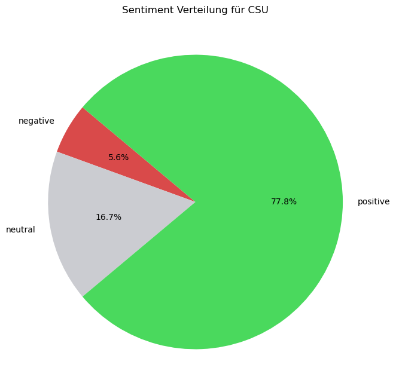

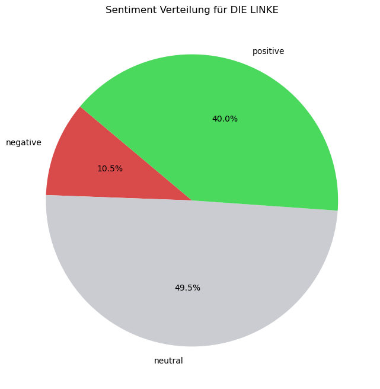

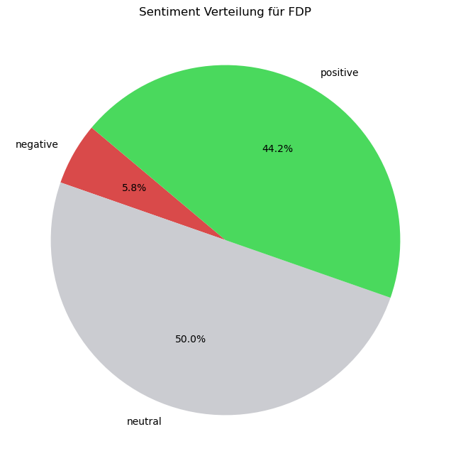

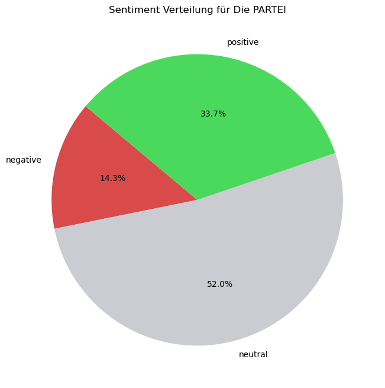

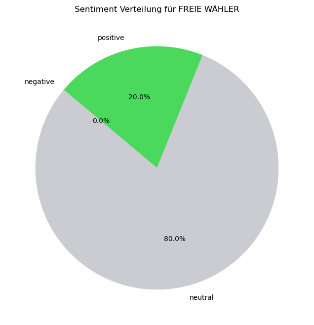

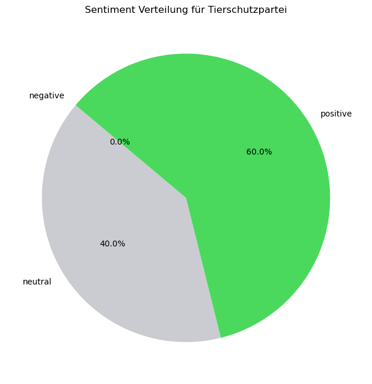

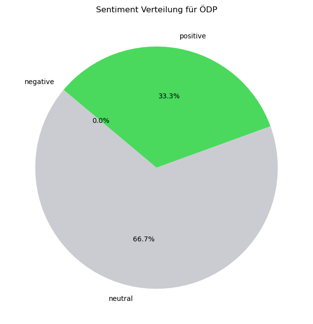

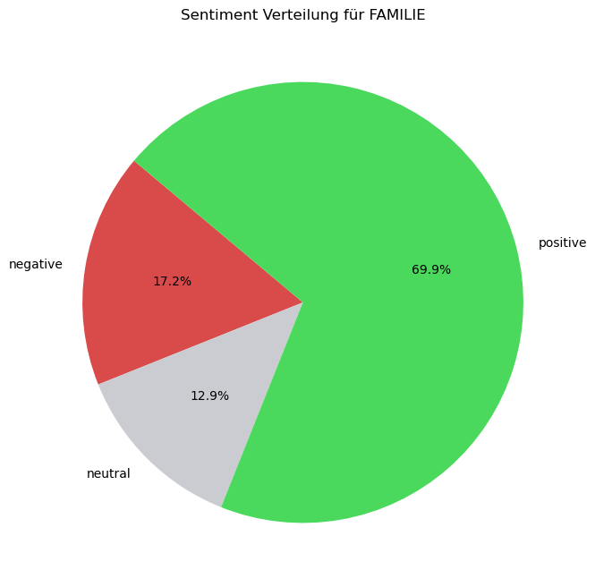

[11 more figures not shown]

```python
color_map = {
    'positive': '#4ad95d',
    'neutral': '#cbccd1',
    'negative': '#d94a4a'
}

# Plotting pie charts for each specified party
for party in parties:
    party_short = party['short']
    party_name = party['name']

    if party_short in sentiment_counts.index:
        # Extract sentiment counts for the specific party
        counts = sentiment_counts.loc[party_short]

        # Colors for the pie chart
        colors = [color_map[sentiment] for sentiment in counts.index]

        # Plot the pie chart
        plt.figure(figsize=(8, 8))
        plt.pie(counts, labels=counts.index, autopct='%1.1f%%', startangle=140, colors=colors)
        plt.title(f'Sentiment Verteilung für {party_short}')
        plt.show()
```

#### Interpretation:

Der dritte Abschnitt der Datenanalyse untersucht die Stimmung der Beiträge, die verschiedene Parteien auf Reddit erwähnen. Dazu wurde eine Sentiment-Analyse durchgeführt, die die Beiträge in positive, neutrale und negative Stimmungen kategorisiert.

Die Verteilung der Sentiments (positive, neutrale und negative Beiträge) kann interessante Aufschlüsse liefern:

- Parteien mit einer hohen Anzahl positiver Erwähnungen könnten von der allgemeinen öffentlichen Zustimmung und Unterstützung profitieren.
- Parteien mit vielen negativen Erwähnungen könnten in der Öffentlichkeit kritischer betrachtet werden oder polarisierend wirken.
- Eine hohe Anzahl neutraler Beiträge könnte auf eine sachliche Diskussion ohne starke emotionale Reaktionen hinweisen.

Diese Einsicht bietet wertvolle Informationen über die Stimmung und öffentliche Wahrnehmung der Parteien auf Reddit. Dies kann nützlich für politische Analysten und Wahlkampfstrategen sein, um die öffentliche Meinung und die Intensität der Diskussionen zu verschiedenen Parteien besser zu verstehen.

### 3.4. Zeitliche Verteilung der Erwähnungen

- Frage: Gibt es zeitliche Trends in der Erwähnung der Parteien?
- Vorgehen: Analyse über die Erwähnungen der Parteien über die Zeit hinweg und identifizierung möglicher Trends und Spitzen
- Visualisierung: Liniendiagramm

#### Analyse:

```python
from datetime import datetime
```

```python
#df_all.dtypes
```

##### Zwischenergebnisse für mich, zum überprüfen der Daten

```python
df_all = df_all.copy()

df_all['Month'] = pd.to_datetime(df_all['created']).dt.strftime('%Y-%m')

df_all.head()
```

|  | subreddit | hashtag | title | score | id | url | num_comments | created | body | author | main_hashtag | sentiment | Month |
| --- | --- | --- | --- | --- | --- | --- | --- | --- | --- | --- | --- | --- | --- |
| 0 | europe | CDU | If next Sunday really were a federal election ... | 843 | 194qwk6 | https://i.redd.it/kj45rngx7zbc1.jpeg | 338 | 2024-01-12 10:16:08 | The drop in polls for BSW is astonishing. In a... | Nohomeoffice | CDU | positive | 2024-01 |
| 1 | europe | CDU | After 4 years of investigation, the Munich Pub... | 146 | 1aelom1 | https://www.tagesspiegel.de/politik/axel-fisch... | 6 | 2024-01-30 11:50:29 | Caviar Diplomacy.\n\nAdditionally, two ex-Germ... | Mobile-Ad-5052 | CDU | neutral | 2024-01 |
| 2 | europe | GRÜNE | If next Sunday really were a federal election ... | 838 | 194qwk6 | https://i.redd.it/kj45rngx7zbc1.jpeg | 338 | 2024-01-12 10:16:08 | The drop in polls for BSW is astonishing. In a... | Nohomeoffice | GRÜNE | positive | 2024-01 |
| 3 | europe | GRÜNE | WWF evaluated all parties in the European Parl... | 0 | 1c5dsqr | https://i.redd.it/s6pqzh1vutuc1.jpeg | 16 | 2024-04-16 13:32:32 | The screenshot only shows members of the EFA/G... | dracona94 | GRÜNE | positive | 2024-04 |
| 4 | europe | GRÜNE | 2024 European Parliament elections | 215 | 1db2gua | https://www.reddit.com/r/europe/comments/1db2g... | 969 | 2024-06-08 15:01:25 | The time has come. This week, citizens of Euro... | pothkan | GRÜNE | positive | 2024-06 |

```python
time_events = df_all[['Month', 'main_hashtag', 'id']]

# Grouping by 'Month' and 'main_hashtag' and counting the occurrences of 'id'
grouped = time_events.groupby(['Month', 'main_hashtag']).count().reset_index()
```

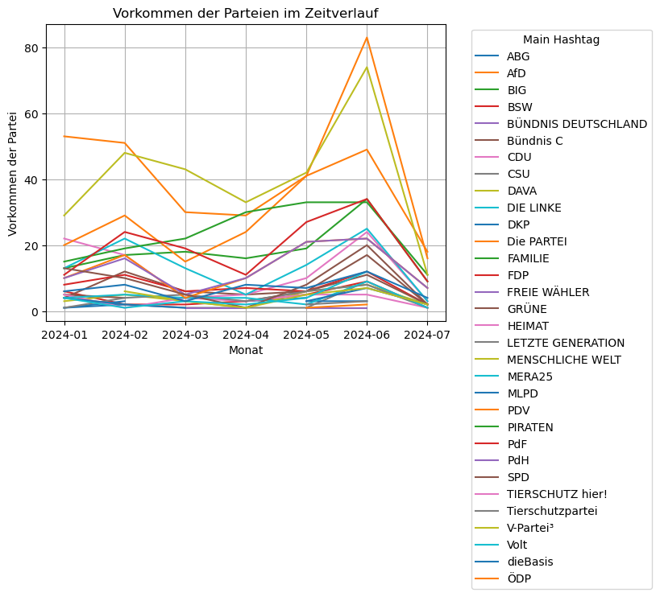

```python
# Pivoting the DataFrame
pivot_df = grouped.pivot(index='Month', columns='main_hashtag', values='id')

# Plotting the line chart
plt.figure(figsize=(10, 10))
pivot_df.plot(kind='line')
plt.title('Vorkommen der Parteien im Zeitverlauf')
plt.xlabel('Monat')
plt.ylabel('Vorkommen der Partei')
plt.legend(title='Main Hashtag', bbox_to_anchor=(1.05, 1), loc='upper left')
plt.grid(True)
plt.show()
```

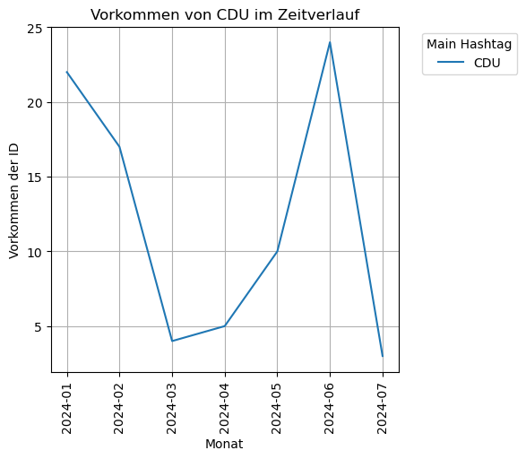

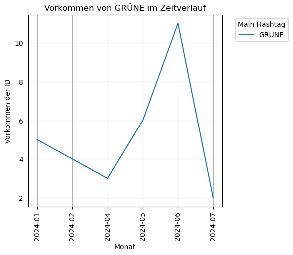

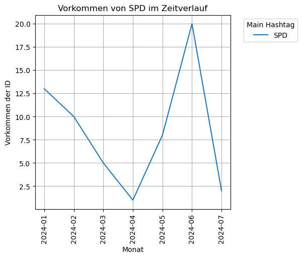

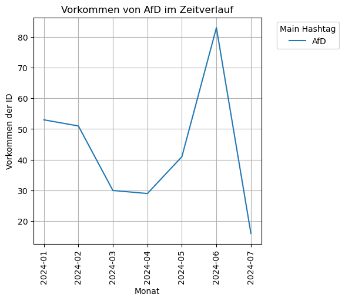

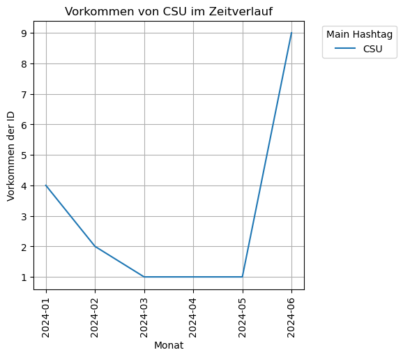

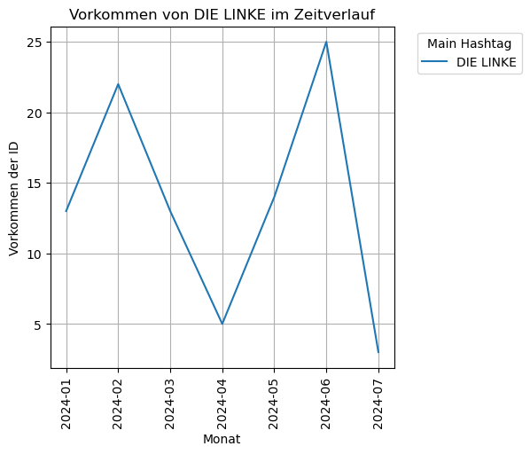

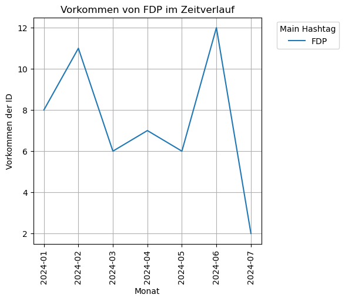

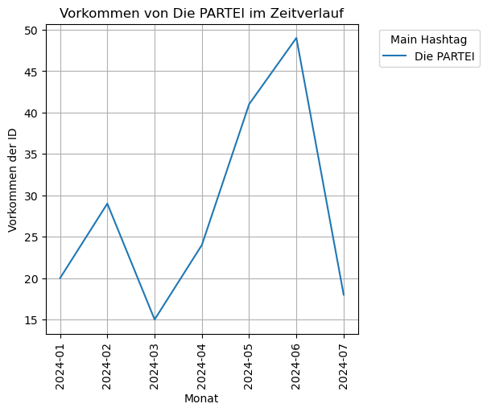

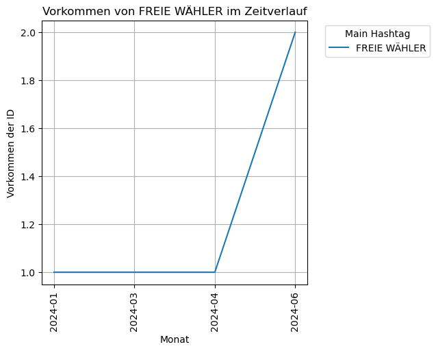

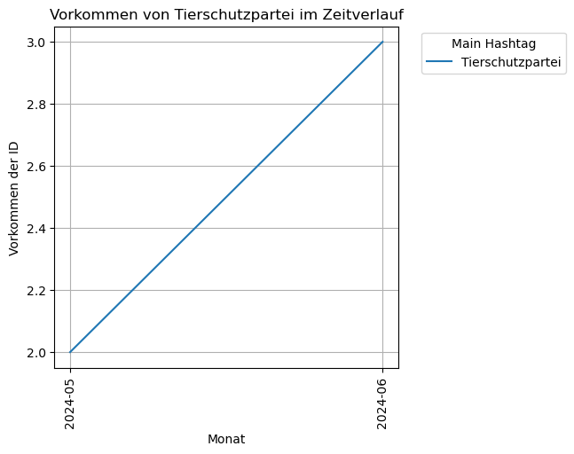

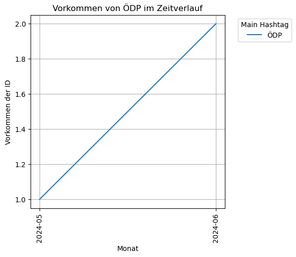

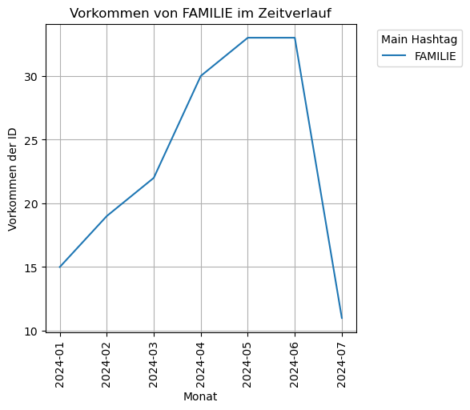

[11 more figures not shown]

```python
for party in parties:
    party_short = party['short']

    # Filtering the DataFrame for the current party's hashtag
    time_events = df_all[df_all['main_hashtag'] == party_short]

    # Grouping by 'Month' and counting the occurrences of 'id'
    grouped = time_events.groupby('Month').count().reset_index()

    # Plotting the line chart
    plt.figure(figsize=(5, 5))
    plt.plot(grouped['Month'], grouped['id'], label=party_short)
    plt.title(f'Vorkommen von {party_short} im Zeitverlauf')
    plt.xlabel('Monat')
    plt.xticks(rotation=90)
    plt.ylabel('Vorkommen der ID')
    plt.legend(title='Main Hashtag', bbox_to_anchor=(1.05, 1), loc='upper left')
    plt.grid(True)
    plt.show()
```

#### Interpretation:

Der vierte Abschnitt der Datenanalyse untersucht die zeitliche Verteilung der Erwähnungen der Parteien auf Reddit. Ziel ist es, mögliche Trends und Spitzen in der Häufigkeit der Erwähnungen im Laufe der Zeit zu identifizieren.

- Kombiniertes Liniendiagramm: Dieses Diagramm zeigt die Anzahl der Beiträge, die jede Partei über die Zeit hinweg erwähnen.
- Separate Liniendiagramme: Diese Diagramme bieten eine detaillierte Visualisierung der Häufigkeit der Erwähnungen für jede Partei über die Zeit.

Die zeitliche Verteilung der Erwähnungen zeigt, dass die Diskussionen über Parteien auf Reddit stark von aktuellen Ereignissen und langfristigen Trends beeinflusst werden. In diesem Fall ist beispielweise klar zu erkennen, dass ende Mai und anfang Juni, bei fast allen Parteien ein klarer Anstieg der Erwähnugen zu verzeichnen ist. Dies ist mit sehr hoher wahrscheinlichkeit auf die Europawahl zurückzuführen.